# Bayesian optimization

04/11/2024

## Targetted applications

## (1): Car crash-worthiness example

10-50 thickness variables

Categorical variables (e.g., materials)

Parts can be present or not

**Goal**: find the best compromise between mass and safety constraints

Simulation time: minutes to hours on HPC

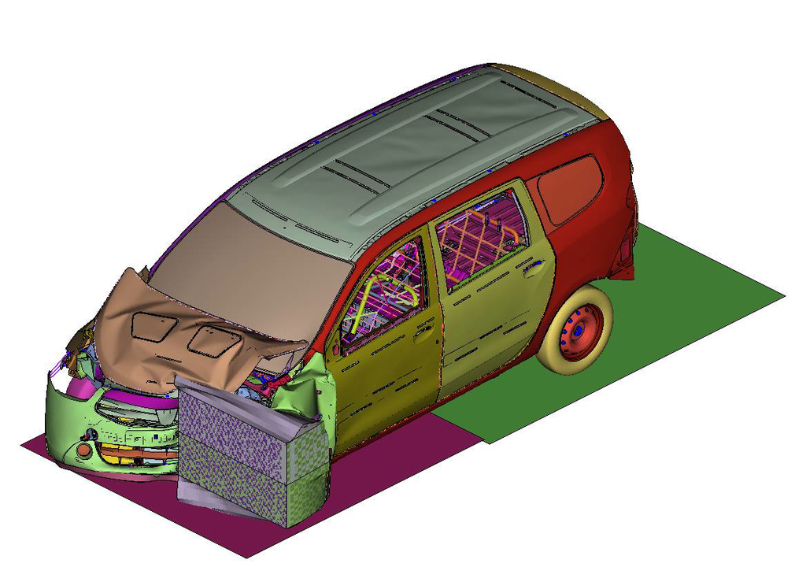

## (2): New York Citi’s Bike System

Allocation of bikes in the city’s dock stations before rush hour.

Variables: number of bikes in 4 groups of stations

Noise: demand for bikes in the simulation period

[figure not shown]

Ref: Toscano-Palmerin, S., & Frazier, P. I. (2018). Bayesian optimization with expensive integrands. arXiv preprint arXiv:1803.08661.

## (3): Hyperparameter optimization

(Convolutional) neural networks show great promises on many problems, but finding an appropriate structure can be time consuming.

These are the so-called **hyperparameter tuning** problems.

*MNIST example*:

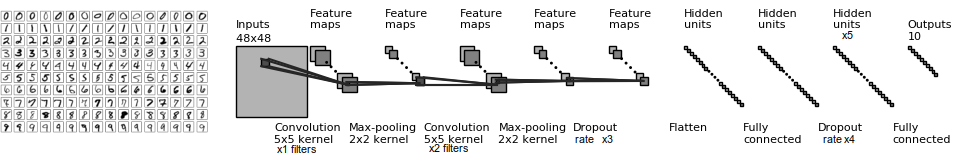

Design variables:

- kernel size, number of filters, number of layers
- dropout rates

“Noise” factors:

- dropout
- initialization
- data set partition

## Initial ideas to tackle these problems?

How to solve \(\min_{\mathbf{x} \in D \subset \mathbf{R}^d} f(\mathbf{x})\) when \(f\) is:

- **expensive**
- **black box**: when no information about the functional form of \(f\) is available (e.g., not convex)
- without derivative information (often)
- possibly **noisy**

Note that we are looking for a **global** minimum here.

Are the optimization methods you know suitable?

## Key ideas (in a nutshell)

1. We replace \(f\) by its model \(\hat{f}\), this is called **surrogate** modeling or metamodeling.
2. We go **sequentially**: one iteration at a time, to update \(\hat{f}\) with new data.
3. We balance between **exploration** of unknown regions of the search space and **exploitation** of promising ones.

**Definition of Bayesian optimization[1]**: Sequential design strategy based on a distribution over functions to define an acquisition function.

[figure not shown]

[1] Mockus, J. (1989).Bayesian approach to global optimization. Springer.

## No free lunch theorem [2]

No silver bullet: no optimizer is best on all possible classes of functions.

Examples of functions out of reach for optimization with small budgets(*):

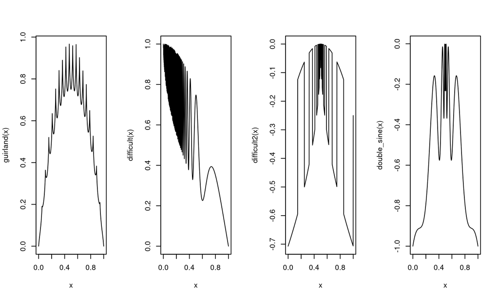

[2] Wolpert, D.H., Macready, W.G. (1997), “No Free Lunch Theorems for Optimization”, IEEE Transactions on Evolutionary Computation 1, 67.

(*) but not for every method, see, e.g., Valko, M., Carpentier, A., & Munos, R. (2013). Stochastic simultaneous optimistic optimization. ICML (pp. 19-27).

## Implementation

Many existing toolboxes in different languages.

Non-exhaustive and biased list:

- Matlab: `BayesianOptimization` in the `stats` toolbox;
- R: packages `DiceOptim`, `laGP`, `GPareto`;
- Python: `trieste`, `SMAC`, `GPyOpt`, `BoTorch`, `SpearMint`